# Predicting Diabetes from Patient Health Metrics

Fall 2024 Data Science Project Michelle Lu

## Introduction: Why Predict Diabetes

Diabetes is a chronic disease that occurs when the pancreas cannot produce enough insulin or cannot effectively use the insulin it produces (WHO). Insulin plays a crucial role in regulating blood glucose levels, and when the body can't manage these glucose levels, it leads to diabetes. According to the World Health Organization, about 11.6% of the U.S. population has diabetes, which is rougly 1 in 10 people (WHO). Mortality rates from diabetes have also been increasing since 2000, and 22.8% of adults with diabetes remain undiagnosed (NIDDK). Given the impact of the disease, predicting diabetes in its early stages can help individuals adjust their lifestyle, and potentially reduce the risk of health complications while lowering mortality rates. This project will walk you through the entire data science cycle to build a machine learning model for predicting diabetes.

For more information on diabetes, visit the resources linked below from the WHO, CDC, and NIDDK:

- [WHO Diabetes Fact Sheet](https://www.who.int/news-room/fact-sheets/detail/diabetes#:~:text=Diabetes%20is%20a%20chronic%20disease,hormone%20that%20regulates%20blood%20glucose.)
- [CDC Diabetes Statistics Report](https://www.cdc.gov/diabetes/php/data-research/index.html)
- [NIDDK Diabetes Statistics](https://www.niddk.nih.gov/health-information/health-statistics/diabetes-statistics)

Before getting into the data, let's import the necessary libraries we need first.

```python
# Import necessary libraries
import pandas as pd
import matplotlib.pyplot as plt
import matplotlib.patches as mpatches
import numpy as np
import seaborn as sns
from scipy.stats import f_oneway, stats, norm, chi2_contingency
from statsmodels.stats.weightstats import ztest as ztest
from statsmodels.stats.multicomp import pairwise_tukeyhsd
from sklearn.model_selection import train_test_split
from sklearn.tree import DecisionTreeClassifier
from sklearn.metrics import classification_report, accuracy_score
from sklearn.utils import resample
from sklearn.tree import plot_tree
```

## Data Curation

The dataset used in this analysis was found on [Kaggle](https://www.kaggle.com/datasets/alexteboul/diabetes-health-indicators-dataset?select=diabetes_binary_health_indicators_BRFSS2015.csv). Kaggle is a data science community that allows users to find datasets. This dataset uses information from the CDC's Behavioral Risk Factor Surveillance System (BRFSS) 2015 survey, which collected data from 253,680 responses. The survey includes information on factors related to diabetes, such as blood pressure, cholesterol levels, BMI, smoking habits, and overall health.

The following is a description of each column in the dataset:

- Diabetes: Diabetes status (No Diabetes or only during pregnancy, Prediabetes, or Diabetes)
- HighBP: Presence of high blood pressure
- HighChol: Presence of high cholesterol
- CholCheck: Whether cholesterol will be checked in the next 5 years
- BMI: Body Mass Index
- Smoker: Whether the individual has smoked at least 100 cigarettes in their lifetime
- Stroke: Whether the individual has had a stroke
- HeartDiseaseorAttack: Presence of heart disease or a heart attack
- PhysActivity: Whether the individual engages in physical activity (not including their job)
- Fruits: Whether the individual consumes fruits 1 or more times a day
- Veggies: Whether the individual consumes vegetables 1 or more times a day
- HvyAlcoholConsump: Whether the individual is a heavy drinker (adult men having more than 14 drinks per week, and adult women having more than 7 drinks per week)
- AnyHealthcare: Whether the individual has healthcare coverage
- NoDocbcCost: Whether cost impacted the individual from seeing a doctor in the past year
- GenHlth: Whether the individual considers they have Excellent, Very Good, Good, Fair, or Poor health
- MentHlth: Number of days in a month with poor mental health
- PhysHlth: Number of days in a month with poor physical health
- DiffWalk: Whether the individual has difficulty walking or climbing stairs
- Sex: Sex of the individual
- Age: Age group of the individual
- Education: Education level of the individual
- Income: Income level of the individual

The dataset given is already cleaned well, with numeric values representing categorical data. To better understand the data, we will replace these numeric values with its corresponding descriptors. Additionally, we will check and drop any rows with NaN values. The final dataframe will include the following columns:

- **diabetes_df:** Diabetes, HighBP, HighChol, CholCheck, BMI, Smoker, Stroke, HeartDiseaseorAttack, PhysActivity, Fruits, Veggies, HvyAlcoholConsump, AnyHealthcare, NoDocbcCost, GenHlth, MentHlth, PhysHlth, DiffWalk, Sex, Age, Education, Income

```python
# Set up dataframe
diabetes_df = pd.read_csv('diabetes_dataset.csv')

# Clean and rearrange data
mappings = {
    'Diabetes_012': {0: 'No Diabetes', 1: 'Prediabetes', 2: 'Diabetes'},
    'HighBP': {0: False, 1: True},
    'HighChol': {0: False, 1: True},
    'CholCheck': {0: False, 1: True},
    'Smoker': {0: False, 1: True},
    'Stroke': {0: False, 1: True},
    'HeartDiseaseorAttack': {0: False, 1: True},
    'PhysActivity': {0: False, 1: True},
    'Fruits': {0: False, 1: True},
    'Veggies': {0: False, 1: True},
    'HvyAlcoholConsump': {0: False, 1: True},
    'AnyHealthcare': {0: False, 1: True},
    'NoDocbcCost': {0: False, 1: True},
    'GenHlth': {1: 'Excellent', 2: 'Very Good', 3: 'Good', 4: 'Fair', 5: 'Poor'},
    'DiffWalk': {0: False, 1: True},
    'Sex': {0: 'Female', 1: 'Male'},
    'Age': {1: '18-24', 2: '25-29', 3: '30-34', 4: '35-39', 5: '40-44', 6: '45-49', 7: '50-54',
            8: '55-59', 9: '60-64', 10: '65-69', 11: '70-74', 12: '75-79', 13: '80+'},
    'Education': {1: 'Never attended school or only kindergarten', 2: 'Elementary', 3: 'Some high school',
                  4: 'High school graduate', 5: 'Some college or technical school', 6: 'College graduate'},
    'Income': {1: 'Less than $10,000', 2: '$10,000-$14,999', 3: '$15,000-$19,999', 4: '$20,000-$24,999',
               5: '$25,000-$34,999', 6: '$35,000-$49,999', 7: '$50,000-$74,999', 8: '$75,000+'}
}

for col, mapping in mappings.items():
    diabetes_df[col] = diabetes_df[col].map(mapping)

# Rename diabetes column
diabetes_df.rename(columns={'Diabetes_012': 'Diabetes'}, inplace=True)

# Drop rows with NaN values
diabetes_df.dropna(inplace=True)

# Display first 5 rows
diabetes_df.head()
```

|  | Diabetes | HighBP | HighChol | CholCheck | BMI | Smoker | Stroke | HeartDiseaseorAttack | PhysActivity | Fruits | ... | AnyHealthcare | NoDocbcCost | GenHlth | MentHlth | PhysHlth | DiffWalk | Sex | Age | Education | Income |
| --- | --- | --- | --- | --- | --- | --- | --- | --- | --- | --- | --- | --- | --- | --- | --- | --- | --- | --- | --- | --- | --- |
| 0 | No Diabetes | True | True | True | 40.0 | True | False | False | False | False | ... | True | False | Poor | 18.0 | 15.0 | True | Female | 60-64 | High school graduate | $15,000-$19,999 |
| 1 | No Diabetes | False | False | False | 25.0 | True | False | False | True | False | ... | False | True | Good | 0.0 | 0.0 | False | Female | 50-54 | College graduate | Less than $10,000 |
| 2 | No Diabetes | True | True | True | 28.0 | False | False | False | False | True | ... | True | True | Poor | 30.0 | 30.0 | True | Female | 60-64 | High school graduate | $75,000+ |
| 3 | No Diabetes | True | False | True | 27.0 | False | False | False | True | True | ... | True | False | Very Good | 0.0 | 0.0 | False | Female | 70-74 | Some high school | $35,000-$49,999 |
| 4 | No Diabetes | True | True | True | 24.0 | False | False | False | True | True | ... | True | False | Very Good | 3.0 | 0.0 | False | Female | 70-74 | Some college or technical school | $20,000-$24,999 |

5 rows × 22 columns

## Exploratory Data Analysis

### The First Hypothesis (Z-Test)

The first hypothesis test we will be using is a [Z-Test](https://www.investopedia.com/terms/z/z-test.asp#:~:text=A%20z%2Dtest%20is%20a%20statistical%20test%20to%20determine%20whether,that%20follows%20a%20normal%20distribution.). A Z-Test is a statistical test used to find whether there is a significant difference between the means of two groups. It is appropriate to use when we have a large sample size and know the population standard deviation. While we do not know the population standard deviation for this dataset, the [Central Limit Theorem](https://www.investopedia.com/terms/c/central_limit_theorem.asp) suggests that with a large sample size, the sampling distribution of the mean tends to follow a normal distribution. As a result, we can assume the sample standard deviation is a good estimate of the population standard deviation.

[Significance level](https://statisticsbyjim.com/glossary/significance-level/) is a measure of the strength of the evidence. It indicates the likelihood of making a [Type 1 error](https://www.scribbr.com/statistics/type-i-and-type-ii-errors/). For the project, we will set the significance level to 0.05 for all hypothesis tests.

```
Z-score: -89.09645700433238
P-value: 0.0
Reject the null hypothesis

No Diabetes Summary Statistic:
count    213703.000000
mean          3.582416
std           7.999205
min           0.000000
25%           0.000000
50%           0.000000
75%           2.000000
max          30.000000
Name: PhysHlth, dtype: float64

Diabetes Summary Statistic:
count    35346.000000
mean         7.954479
std         11.301491
min          0.000000
25%          0.000000
50%          1.000000
75%         15.000000
max         30.000000
Name: PhysHlth, dtype: float64
```

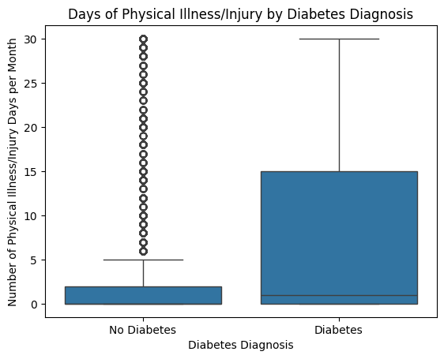

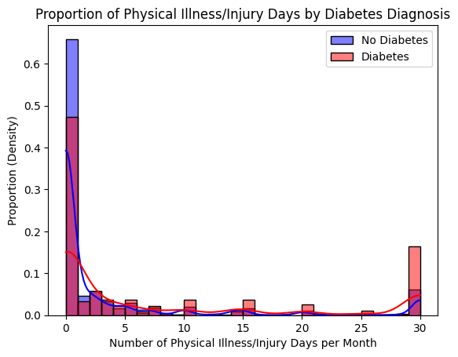

```python
# Separate data into two groups, no diabetes and diabetes
no_diabetes_df = diabetes_df[diabetes_df['Diabetes'] == 'No Diabetes']
has_diabetes_df = diabetes_df[diabetes_df['Diabetes'] == 'Diabetes']

# Calculate the sample statistics
no_diabetes_summary_stats = no_diabetes_df['PhysHlth'].describe()
has_diabetes_summary_stats = has_diabetes_df['PhysHlth'].describe()

# Calculate z-score and p-value
z_score, p_value = ztest(no_diabetes_df['PhysHlth'], has_diabetes_df['PhysHlth'])
print(f"Z-score: {z_score}")
print(f"P-value: {p_value}")

# Conclusion
alpha = 0.05
if p_value < alpha:
    print("Reject the null hypothesis\n")
else:
    print("Fail to reject the null hypothesis\n")

print(f"No Diabetes Summary Statistic:\n{no_diabetes_summary_stats}\n")
print(f"Diabetes Summary Statistic:\n{has_diabetes_summary_stats}\n")

# Create box plot
sns.boxplot(x='Diabetes', y='PhysHlth', data=diabetes_df, order=['No Diabetes', 'Diabetes'])
plt.title('Days of Physical Illness/Injury by Diabetes Diagnosis')
plt.xlabel('Diabetes Diagnosis')
plt.ylabel('Number of Physical Illness/Injury Days per Month')
plt.show()

# Create histogram
sns.histplot(data=no_diabetes_df, x='PhysHlth', color='blue', label='No Diabetes', kde=True, bins=30, stat='density')
sns.histplot(data=has_diabetes_df, x='PhysHlth', color='red', label='Diabetes', kde=True, bins=30, stat='density')
plt.title('Proportion of Physical Illness/Injury Days by Diabetes Diagnosis')
plt.xlabel('Number of Physical Illness/Injury Days per Month')
plt.ylabel('Proportion (Density)')
plt.legend()
plt.show()
```

#### Interpreting the Z-Score and P-Value

[Z-Score](https://www.statisticshowto.com/probability-and-statistics/z-score/) is a value describing how far a value is from the mean of the dataset. The z-score of this dataset (-89.09) is an extremely large negative number, indicating that the average number of physical illness/injury days per month of non-diabetics are significantly lower than of diabetics. Note that this does not include the diagnosis for prediabetes. A [p-value](https://www.investopedia.com/terms/p/p-value.asp#:~:text=A%20p%2Dvalue%20measures%20the,is%20generally%20considered%20statistically%20significant.) is the probability that the null hypothesis is correct. Since the p-value (0.0) is 0 and much smaller than our significance level (0.05), we reject the null hypothesis. This means there is strong evidence that a significant difference exists in the average number of physical illness/injury days per month between non-diabetics and diabetics. The p-value suggests that the likelihood of obtaining these results if the null hypothesis were true is zero. Therefore, we can confidently conclude that there is a significant difference in physical health for non-diabetics and diabetics, with non-diabetics having better physical health than diabetics. This difference suggests that physical health could have an impact on diabetes diagnosis, or vice versa. However, more research is needed to better understand the connection between the two.

### The Second Hypothesis (Chi-Squared Test)

The second hypothesis test I will be using is a [Chi-Squared Test](https://www.investopedia.com/terms/c/chi-square-statistic.asp). Chi-Squared Tests checks if two sets of categorical variables come from the same distribution.

- **H0:** Sex does not have an impact on the likelihood of having diabetes.
- **HA:** Sex does have an impact on the likelihood of having diabetes.

```
Chi-Squared Statistic: 250.85057509520166
P-value: 3.376678611575899e-55
Degrees of Freedom: 2
Expected Frequencies: [[ 19781.66589404  15564.33410596]
 [119600.55866446  94102.44133554]
 [  2591.7754415    2039.2245585 ]]
Reject the null hypothesis
```

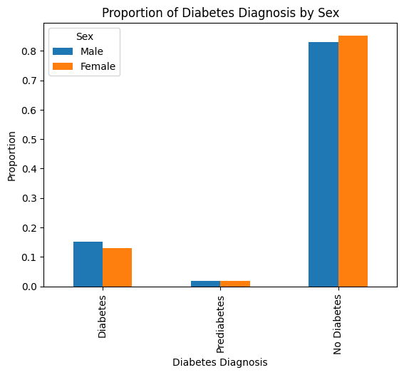

```python
# Use Chi-Squared Test to compare sex and diabetes status

# Create a contingency table
contingency_table = pd.crosstab(diabetes_df['Diabetes'], diabetes_df['Sex'])

# Perform Chi-Square test
chi2_stat, p_value, dof, expected = chi2_contingency(contingency_table)
print(f'Chi-Squared Statistic: {chi2_stat}')
print(f'P-value: {p_value}')
print(f'Degrees of Freedom: {dof}')
print(f'Expected Frequencies: {expected}')

# Conclusion
alpha = 0.05
if p_value < alpha:
    print("Reject the null hypothesis\n")
else:
    print("Fail to reject the null hypothesis\n")

# Convert contingency table to proportions by sex
proportions_by_sex = contingency_table.div(contingency_table.sum(axis=0), axis=1)
proportions_by_sex = proportions_by_sex.loc[['Diabetes', 'Prediabetes', 'No Diabetes'], ['Male', 'Female']]

# Plot proportional bar chart
proportions_by_sex.plot(kind="bar")
plt.title('Proportion of Diabetes Diagnosis by Sex')
plt.xlabel('Diabetes Diagnosis')
plt.ylabel('Proportion')
plt.legend(title='Sex')
plt.show()
```

#### Interpreting the P-Value

Based on the p-value (3.37e-55), we reject the null hypothesis because it is less than our significance level (0.05). This means there is strong evidence that sex does impact the likelihood of having diabetes. The p-value suggests that the likelihood of obtaining these results if the null hypothesis were true is essentially zero. Therefore, we can confidently conclude that sex does impact the likelihood of having diabetes.

### The Last Hypothesis (ANOVA Test)

The last hypothesis test we will be using is an ANOVA (Analysis of Variance) Test. [ANOVA](https://www.scribbr.com/statistics/one-way-anova/#:~:text=ANOVA%2C%20which%20stands%20for%20Analysis,ANOVA%20uses%20two%20independent%20variables.) is another statistical test that compares the means of multiple groups to determine if there are significant differences among them.

- **H0:** There is no difference in the average BMI between diabetes diagnoses.
- **HA:** There is a difference in the average BMI between diabetes diagnoses.

```
P-value: 0.0
Reject the null hypothesis
```

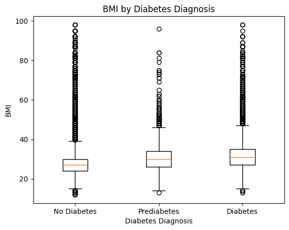

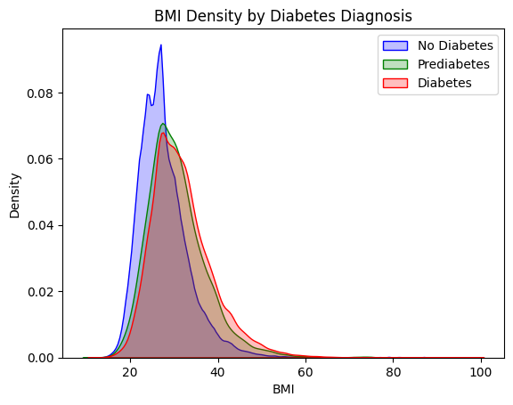

```python
# Use ANOVA Test to compare BMI and diabetes status

# Split data into different dfs based on diabetes status
no_diabetes_df = diabetes_df[diabetes_df['Diabetes'] == 'No Diabetes']
pre_diabetes_df = diabetes_df[diabetes_df['Diabetes'] == 'Prediabetes']
has_diabetes_df = diabetes_df[diabetes_df['Diabetes'] == 'Diabetes']

# Get bmi of different diabetes status
no_diabetes_bmi = no_diabetes_df['BMI']
pre_diabetes_bmi = pre_diabetes_df['BMI']
has_diabetes_bmi = has_diabetes_df['BMI']

# Perform ANOVA test
f_statistic, p_value = f_oneway(no_diabetes_bmi, pre_diabetes_bmi, has_diabetes_bmi)
print(f'P-value: {p_value}')

# Conclusion
alpha = 0.05
if p_value < alpha:
    print("Reject the null hypothesis\n")
else:
    print("Fail to reject the null hypothesis\n")

# Create box plot
data = [no_diabetes_bmi, pre_diabetes_bmi, has_diabetes_bmi]
plt.boxplot(data, labels=['No Diabetes', 'Prediabetes', 'Diabetes'])
plt.title('BMI by Diabetes Diagnosis')
plt.xlabel('Diabetes Diagnosis')
plt.ylabel('BMI')
plt.show()

# Create KDE Plot
sns.kdeplot(no_diabetes_bmi, fill=True, label='No Diabetes', color='blue')
sns.kdeplot(pre_diabetes_bmi, fill=True, label='Prediabetes', color='green')
sns.kdeplot(has_diabetes_bmi, fill=True, label='Diabetes', color='red')
plt.title('BMI Density by Diabetes Diagnosis')
plt.xlabel('BMI')
plt.ylabel('Density')
plt.legend()
plt.show()
```

#### Interpreting the P-Value

```
     Multiple Comparison of Means - Tukey HSD, FWER=0.05
=============================================================
   group1      group2   meandiff p-adj  lower   upper  reject
-------------------------------------------------------------
   Diabetes No Diabetes  -4.2015   0.0 -4.2881 -4.1148   True
   Diabetes Prediabetes  -1.2195   0.0 -1.4554 -0.9837   True
No Diabetes Prediabetes   2.9819   0.0  2.7578  3.2061   True
-------------------------------------------------------------
```

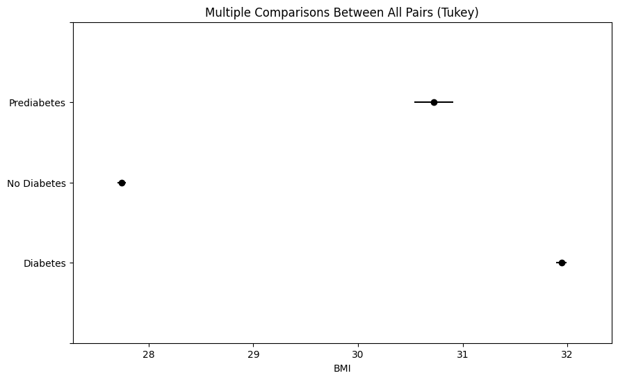

```python
# Perform a Tukey Post Hoc Test
tukey_result = pairwise_tukeyhsd(endog=diabetes_df['BMI'], groups=diabetes_df['Diabetes'], alpha=0.05)
print(tukey_result)

tukey_result.plot_simultaneous()
plt.xlabel('BMI')
plt.show()
```

# Primary Analysis

After exploring the dataset, classification would be the most appropriate method for this analysis. Classification is a type of supervised learning that works well with labeled data. The dataset we are using specifies whether a patient has no diabetes, prediabetes, or diabetes, therefore classification would work best.

Although clustering could be considered as an alternative, it is not ideal for this scenario. Clustering is a type of unsupervised learning used for unlabeled data. Since we already know each patient's diabetes status, clustering may be redundant when it comes to classifying a patient.

Follow these links to learn more:

- [Supervised vs Unsupervised Learning](https://www.geeksforgeeks.org/supervised-unsupervised-learning/)
- [Classification vs Clustering](https://www.geeksforgeeks.org/ml-classification-vs-clustering/)

```python
# Filter out 'Prediabetes' samples as we will only focus on identifying diabetes and non-diabetes patients
diabetes_filtered_df = diabetes_df[diabetes_df['Diabetes'] != 'Prediabetes']

# Separate diabetes and non-diabetes rows
diabetes_yes = diabetes_filtered_df[diabetes_filtered_df['Diabetes'] == 'Diabetes']
diabetes_no = diabetes_filtered_df[diabetes_filtered_df['Diabetes'] == 'No Diabetes']

# Undersample diabetes data to match no diabetes data
diabetes_no_undersampled = resample(
    diabetes_no,
    replace=False,
    n_samples=len(diabetes_yes),
    random_state=42
)

# Combine the classes and shuffle the dataset
balanced_df = pd.concat([diabetes_yes, diabetes_no_undersampled])
balanced_df = balanced_df.sample(frac=1, random_state=42)

# Define features and target
columns_to_drop = ['Diabetes', 'Education', 'Income', 'AnyHealthcare']
X = balanced_df.drop(columns=columns_to_drop)
y = balanced_df['Diabetes']
X = pd.get_dummies(X, drop_first=True) # One-hot encoding for categorical variables

# Split into train and test sets
X_train, X_test, y_train, y_test = train_test_split(X, y, test_size=0.2, random_state=42)
```

A [Decision Tree](https://www.geeksforgeeks.org/decision-tree/) Classifier is used because it is easy to interpret and can handle both numerical and categorical data, which our dataset has. Additionally, it was found that a max_depth of 7 gave the highest accuracy, as having too high or too low max_depth can decrease the accuracy.

```python
# Build and train Decision Tree model
rf_model = DecisionTreeClassifier(criterion='entropy', class_weight='balanced', max_depth=7, splitter='best', min_samples_leaf=50)
rf_model.fit(X_train, y_train)

# Test the model
y_pred = rf_model.predict(X_test)

# Print model metrics
print("Accuracy:", accuracy_score(y_test, y_pred))
print("\nClassification Report:\n", classification_report(y_test, y_pred))
```

```
Accuracy: 0.733361623877219

Classification Report:
               precision    recall  f1-score   support

    Diabetes       0.71      0.78      0.74      6979
 No Diabetes       0.76      0.69      0.72      7160

    accuracy                           0.73     14139
   macro avg       0.74      0.73      0.73     14139
weighted avg       0.74      0.73      0.73     14139
```

The model achieved a 73.3% accuracy, indicating it should not be used as a definitive tool for diagnosing diabetes. Instead, it should serve as a screening tool to identify patients who may have diabetes. The [classification report](https://developers.google.com/machine-learning/crash-course/classification/accuracy-precision-recall) shows the model performs better on recall than precision for diabetes classification, meaning it does well for making sure it catches all diabetes patients. On the other hand, the model performs better at precision than recall for no diabetes classification, meaning it does well at making sure someone classified as having no diabetes has no diabetes. Therefore, this model should not be used to diagnose someone with or without diabetes, but as an indicator of whether they should seek a doctor on their diabetes status.

Let's visualize what our machine learning model looks like.

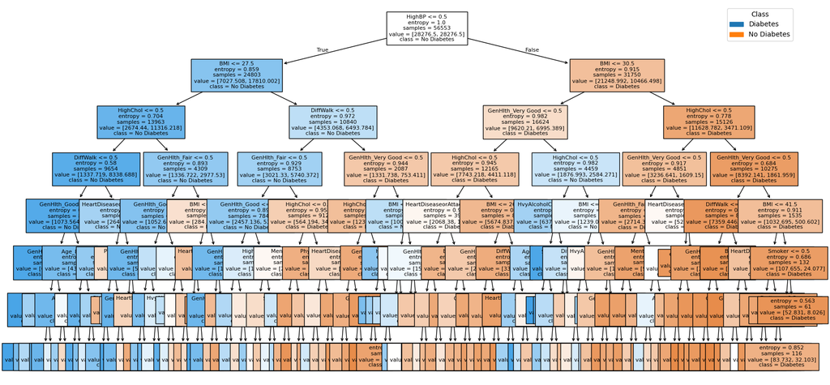

```python
# Visualize the decision tree
plt.figure(figsize=(20, 10))
tree_plot = plot_tree(
    rf_model,
    feature_names=X.columns,
    class_names=rf_model.classes_,
    filled=True,
    fontsize=8
)

# Create legend
colors = [plt.cm.tab10(i) for i in range(len(rf_model.classes_))]
classes = [
    mpatches.Patch(color=color, label=cls)
    for cls, color in zip(rf_model.classes_, colors)
]

# Add legend to plot
plt.legend(
    handles=classes,
    title="Class",
    loc="upper right"
)

plt.show()
```

This visualization shows the decision tree with the features, class labels, entropy, and number of samples in each node. The colors in each node show the level of certainty about whether or not a person has diabetes or not, based on the given features. The tree's large size reflects how individual features alone are not sufficient enough to determine someone's diabetes status. However, when the features are combined, these features are better indicators of whether someone has diabetes.

Let's see which features have the greatest influence on diabetes classification.

```
                 Feature  Importance
0                 HighBP    0.459052
3                    BMI    0.167733
1               HighChol    0.082941
18     GenHlth_Very Good    0.065847
15          GenHlth_Fair    0.054819
14              DiffWalk    0.054252
16          GenHlth_Good    0.048733
17          GenHlth_Poor    0.025189
6   HeartDiseaseorAttack    0.013512
31               Age_80+    0.006430
29             Age_70-74    0.004697
10     HvyAlcoholConsump    0.003855
2              CholCheck    0.002428
12              MentHlth    0.002175
```

[output cut: 18 more lines]

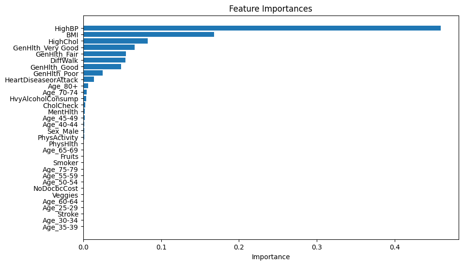

```python
# Find feature importances in the decision tree
importances = rf_model.feature_importances_
feature_names = X.columns
feature_importance = pd.DataFrame({'Feature': feature_names, 'Importance': importances})
print(feature_importance.sort_values(by='Importance', ascending=False))

# Visualize feature importances
indices = importances.argsort()
plt.figure(figsize=(10, 6))
plt.title('Feature Importances')
plt.barh(range(len(indices)), importances[indices], align='center')
plt.yticks(range(len(indices)), [X.columns[i] for i in indices])
plt.xlabel('Importance')
plt.show()
```

This graph shows that the most significant indicators or diabetes are high blood pressure, followed by BMI and high cholesterol. These align with diabetes patients, as many diabetics have high blood pressure, high BMI, and high cholesterol. The least significant indicators are specific age ranges, if they had a stroke before, whether cost impacted the individual from seeing a doctor in the past year, and whether they eat one vegetable a day.

## Insights and Conclusions

The machine learning model shows that predicting diabetes based on non-symptomatic features is difficult. More indicators are needed to accurately predict if someone has diabetes. While the model is only 73% accurate, it still serves as a useful tool for individuals who suspect they have diabetes and should talk with their doctor. Based on the given dataset, the main indicators of diabetes are whether someone has high blood pressure, high cholesterol, and high BMI.

With more patient data, it will become easier to identify diabetes, similar to how doctors diagnose, by gathering all symptoms and using it to assess the likelihood of having diabetes.